# Github for collaboration

```r
library(readr)
library(broom)
library(ggplot2)
library(openintro) #NEW - install this first!
library(GGally) #NEW- install this first!
library(tidyverse)
library(ggmosaic)
library(moderndive)
```

```r
athletes <- read.csv("/Users/carrieshao/Downloads/athletes/athlete_events.csv")
```

1.graphs

The graph shows the relationship between age and medal categories for olympic competitors. We can see from the graph that bronze, gold and silver medal winners, along with other participants without medals all have relatively similar ages as the bars overlap in their heights and the median are all kept around 25. The IQR for all three medals are all relatively same. Thus there is no huge impact of age to the medal level. Competitors without medal has a higher range of age (about 100) than medal winners. Gold medal winners have the smallest range of age. All three medal winners’ and other participants’ ages are pretty right skewed. It’s interesting to see that there are quite a lot of people over 75 participating in olympic, even though they didn’t win medals. Those won the medals are all under 75 years old.

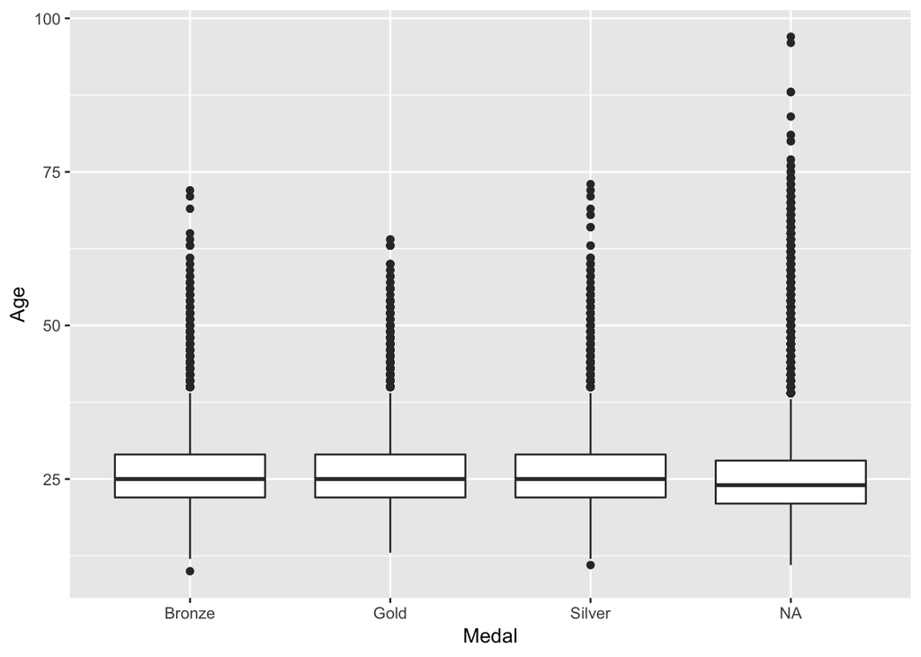

```r
ggplot(data = athletes , aes(y = Age, x = Medal)) + geom_boxplot()
```

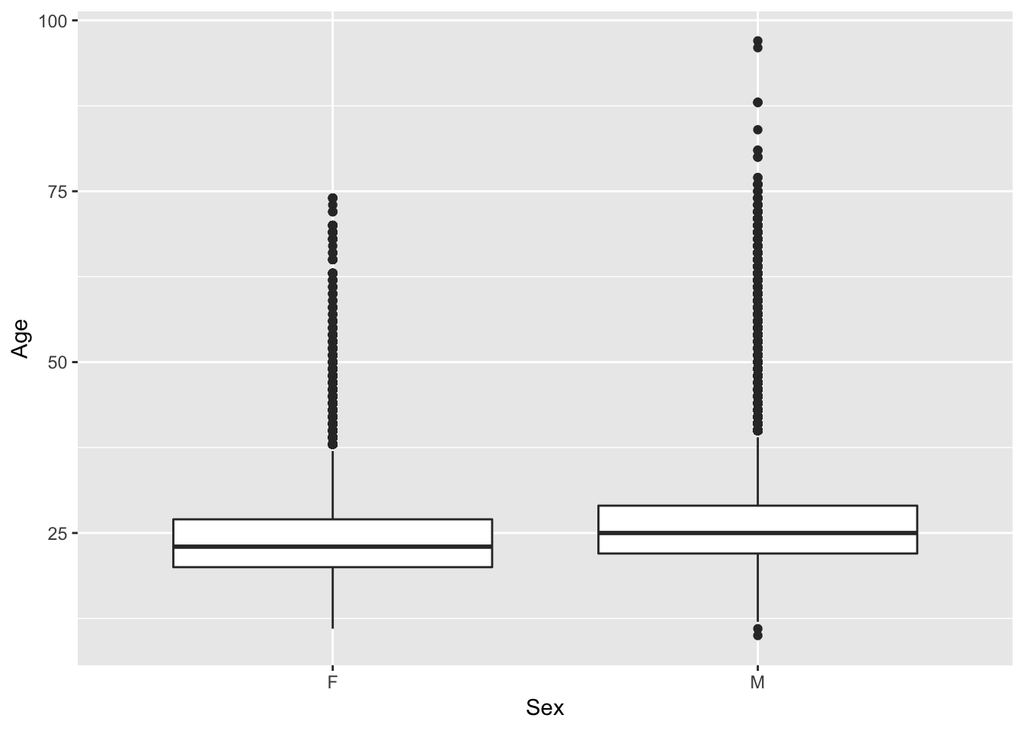

```r
ggplot(data = athletes , aes(y = Age, x = Sex)) + geom_boxplot()
```

The graph shows the relationship between sex and age for olympic competitors. We can see from the graph that males olympic competitors have higher age median, but both males and females have relatively similar ages as their boxes overlap. What’s more interesting in this graph is that males tend to have higher age range (about 100) than women (about 75). Both ages for are right skewed.

4. future work The future work that we think we would like to do is to explore our dataset both in breadth and in depth. We want to examine more graphs and models that involve a variety of variables, each may show relationships between two or more variables and explain completely different things. At the same time, we want to come up with a single topic of what may affect the number of medals won by a single entity (country, person, etc.). From here we will examine more variables that explain the effect and result. We will make more models, graphs to explore the relationship and come up with decent explnations for the result.

2 & 3. models and their inferences

```r
Lm.weight <- lm(Weight ~ Age,data = athletes)
tidy(Lm.weight)
```

```
## # A tibble: 2 x 5
##   term        estimate std.error statistic p.value
##   <chr>          <dbl>     <dbl>     <dbl>   <dbl>
## 1 (Intercept)   56.8     0.144       394.        0
## 2 Age            0.555   0.00561      98.8       0
```

```r
set.seed(543)

Weight_Age <-
  athletes %>%
  rep_sample_n(size = 300, replace = FALSE, reps = 300) %>%
  group_by(replicate) %>%
  mutate(new_Weight = sample(Weight)) %>%
  do(lm(new_Weight ~ Age, data=.) %>% tidy())
```

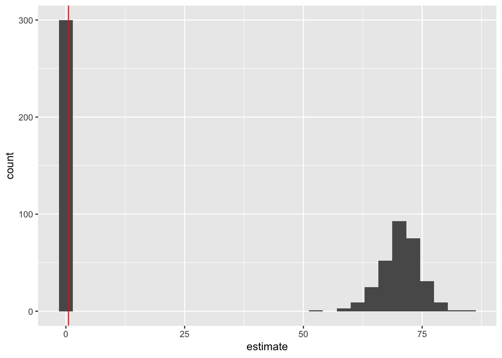

```r
Weight_Age %>%
  ggplot(aes(x = estimate)) +
  geom_histogram(bins = 30) +
  geom_vline(xintercept = 0.5546711, color = "red")
```

```r
Lm.Height <- lm(Height ~ Age,data = athletes)
tidy(Lm.Height)
```

```
## # A tibble: 2 x 5
##   term        estimate std.error statistic p.value
##   <chr>          <dbl>     <dbl>     <dbl>   <dbl>
## 1 (Intercept)  169.      0.106      1598.        0
## 2 Age            0.263   0.00411      64.0       0
```

```r
set.seed(543)

Height_Age <-
  athletes %>%
  rep_sample_n(size = 300, replace = FALSE, reps = 300) %>%
  group_by(replicate) %>%
  mutate(new_Height = sample(Height)) %>%
  do(lm(new_Height ~ Age, data=.) %>% tidy())
```

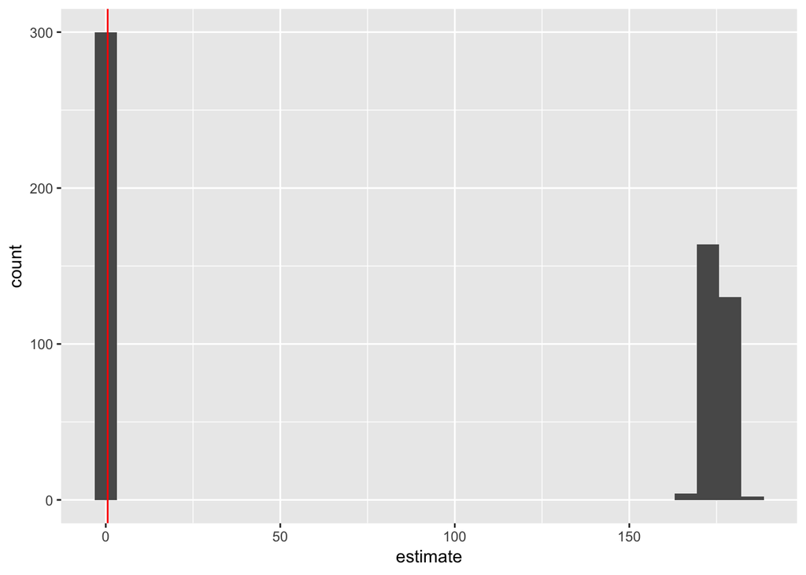

```r
Height_Age %>%
  ggplot(aes(x = estimate)) +
  geom_histogram(bins = 30) +
  geom_vline(xintercept = 0.5546711, color = "red")
```

```r
Lm.HW <- lm(Height ~ Weight, data = athletes)
tidy(Lm.HW)
```

```
## # A tibble: 2 x 5
##   term        estimate std.error statistic p.value
##   <chr>          <dbl>     <dbl>     <dbl>   <dbl>
## 1 (Intercept)  134.     0.0706       1898.       0
## 2 Weight         0.586  0.000979      599.       0
```

```r
set.seed(543)

Weight_Height <-
  athletes %>%
  rep_sample_n(size = 300, replace = FALSE, reps = 300) %>%
  group_by(replicate) %>%
  mutate(new_Height = sample(Height)) %>%
  do(lm(Height ~ Weight, data=.) %>% tidy())
```

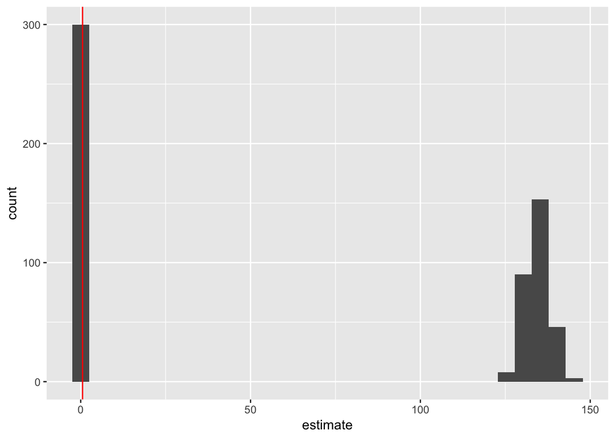

```r
Weight_Height %>%
  ggplot(aes(x = estimate)) +
  geom_histogram(bins = 30) +
  geom_vline(xintercept = 0.5546711, color = "red")
```

```r
medal_age <- lm(Age ~ Sex,
                   data= athletes)
get_regression_table(medal_age)
```

```
## # A tibble: 2 x 7
##   term      estimate std_error statistic p_value lower_ci upper_ci
##   <chr>        <dbl>     <dbl>     <dbl>   <dbl>    <dbl>    <dbl>
## 1 intercept    23.7      0.023    1027.        0    23.7     23.8
## 2 SexM          2.54     0.027      93.2       0     2.49     2.60
```